# Analysis for Views of Science and the Future

## Data Summary

```
## 'data.frame':    1001 obs. of  51 variables:
##  $ psraid  : int  100009 100019 100021 100033 100034 100036 100045 100050 100052 100055 ...
##  $ sample  : int  1 1 1 1 1 1 1 1 1 1 ...
##  $ form    : int  1 1 2 2 1 1 2 1 2 2 ...
##  $ int_date: int  21314 21314 21314 21714 21314 21314 21714 21314 21314 21314 ...
##  $ lang    : int  1 1 1 1 1 1 1 1 1 1 ...
##  $ state   : int  47 1 17 24 37 27 27 12 25 18 ...
##  $ cregion : int  3 3 2 3 3 2 2 3 1 2 ...
##  $ density : int  3 2 1 4 4 3 5 2 4 3 ...
##  $ usr     : Factor w/ 3 levels "R","S","U": 2 2 1 2 3 2 3 2 2 3 ...
##  $ pial1a  : int  1 1 NA NA 8 2 NA 1 NA NA ...
##  $ pial1b  : int  NA NA 2 2 NA NA 8 NA 2 8 ...
##  $ pial2a  : int  1 1 2 3 5 2 1 4 3 4 ...
##  $ pial2b  : int  1 2 2 2 5 2 2 4 8 3 ...
##  $ pial2c  : int  4 2 2 4 3 4 3 4 3 3 ...
```

[output cut: 37 more lines]

```
##      psraid           sample         form         int_date
##  Min.   :100009   Min.   :1.0   Min.   :1.00   Min.   :21314
##  1st Qu.:100602   1st Qu.:1.0   1st Qu.:1.00   1st Qu.:21514
##  Median :200005   Median :2.0   Median :2.00   Median :21614
##  Mean   :150814   Mean   :1.5   Mean   :1.51   Mean   :21574
##  3rd Qu.:200817   3rd Qu.:2.0   3rd Qu.:2.00   3rd Qu.:21714
##  Max.   :202149   Max.   :2.0   Max.   :2.00   Max.   :21814
##
##       lang           state          cregion         density     usr
##  Min.   :1.000   Min.   : 1.00   Min.   :1.000   Min.   :1.00   R:217
##  1st Qu.:1.000   1st Qu.:12.00   1st Qu.:2.000   1st Qu.:2.00   S:457
##  Median :1.000   Median :29.00   Median :3.000   Median :3.00   U:327
##  Mean   :1.049   Mean   :28.64   Mean   :2.679   Mean   :2.84
##  3rd Qu.:1.000   3rd Qu.:42.00   3rd Qu.:3.000   3rd Qu.:4.00
##  Max.   :2.000   Max.   :56.00   Max.   :4.000   Max.   :5.00
##
##      pial1a          pial1b          pial2a          pial2b
##  Min.   :1.000   Min.   :1.000   Min.   :1.000   Min.   :1.000
##  1st Qu.:1.000   1st Qu.:1.000   1st Qu.:2.000   1st Qu.:2.000
##  Median :1.000   Median :2.000   Median :2.000   Median :2.000
##  Mean   :2.231   Mean   :2.454   Mean   :2.728   Mean   :2.202
##  3rd Qu.:2.000   3rd Qu.:2.000   3rd Qu.:3.000   3rd Qu.:2.000
##  Max.   :9.000   Max.   :9.000   Max.   :9.000   Max.   :8.000
##  NA's   :511     NA's   :490
##      pial2c          pial2d          pial2e          pial3a
##  Min.   :1.000   Min.   :1.000   Min.   :1.000   Min.   :1.000
##  1st Qu.:2.000   1st Qu.:3.000   1st Qu.:2.000   1st Qu.:1.000
##  Median :3.000   Median :3.000   Median :3.000   Median :2.000
##  Mean   :3.069   Mean   :3.356   Mean   :3.002   Mean   :2.073
##  3rd Qu.:4.000   3rd Qu.:4.000   3rd Qu.:4.000   3rd Qu.:2.000
##  Max.   :9.000   Max.   :9.000   Max.   :9.000   Max.   :9.000
##
##      pial3b          pial3c          pial3d          pial4a
##  Min.   :1.000   Min.   :1.000   Min.   :1.000   Min.   :1.000
##  1st Qu.:2.000   1st Qu.:1.000   1st Qu.:2.000   1st Qu.:2.000
##  Median :2.000   Median :2.000   Median :2.000   Median :2.000
##  Mean   :2.407   Mean   :2.098   Mean   :2.112   Mean   :1.937
##  3rd Qu.:2.000   3rd Qu.:2.000   3rd Qu.:2.000   3rd Qu.:2.000
##  Max.   :9.000   Max.   :9.000   Max.   :9.000   Max.   :9.000
##
```

[output cut: 49 more lines]

```
##                  :984                :687                  :966
##  HISPANIC        :  6   FLYING CAR   : 29   BAPTIST        :  4
##  LATINO          :  4   A FLYING CAR :  7   WICCAN         :  4
##  MEXICAN         :  6   TELEPORTER   :  7   AGNOSTIC       :  1
##  MEXICAN AMERICAN:  1   FLYING CARS  :  6   APOSTILC       :  1
##                         TELEPORTATION:  5   ASSEMBLY OF GOD:  1
##                         (Other)      :260   (Other)        : 24
##     zipcode          weight         standwt
##  Min.   : 1073   Min.   :1.000   Min.   :0.3064
##  1st Qu.:27616   1st Qu.:1.700   1st Qu.:0.5209
##  Median :52241   Median :2.767   Median :0.8478
##  Mean   :52985   Mean   :3.264   Mean   :1.0000
##  3rd Qu.:82012   3rd Qu.:4.400   3rd Qu.:1.3482
##  Max.   :99999   Max.   :7.467   Max.   :2.2879
##
```

There are 1001 adults data in the dataset with 51 variables (psraid, sample, form, int_date, …, standwt).

## PIAL 1A: Future will be Better or Worse?

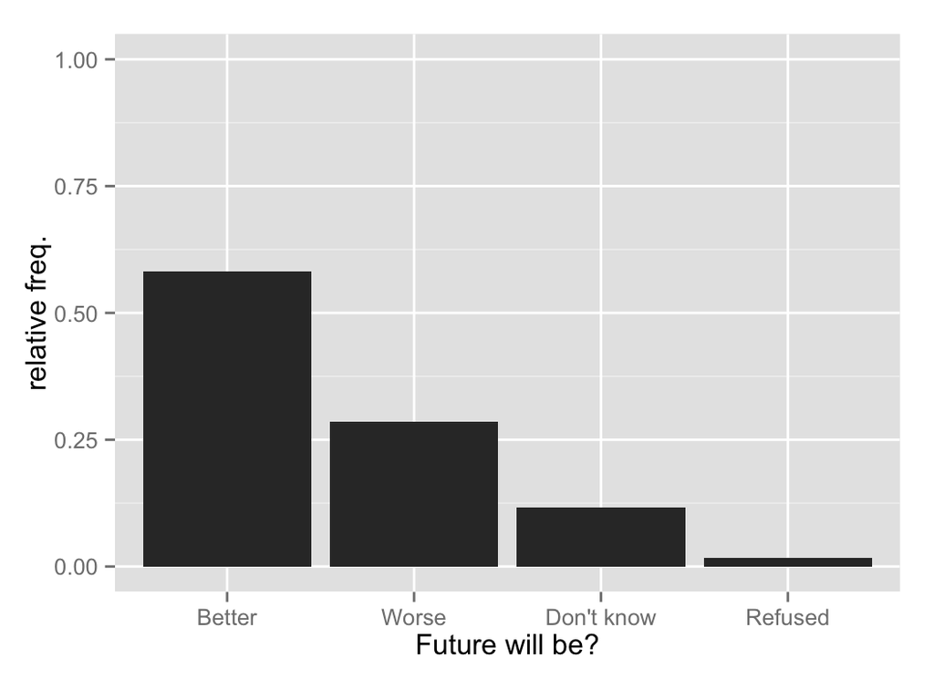

```
## Source: local data frame [2 x 2]
##
##   pial1a == 1   n
## 1       FALSE 205
## 2        TRUE 285
```

58.1% (285/490) think the future will be better.

## PIAL 1B: Future will be Worse or Better?

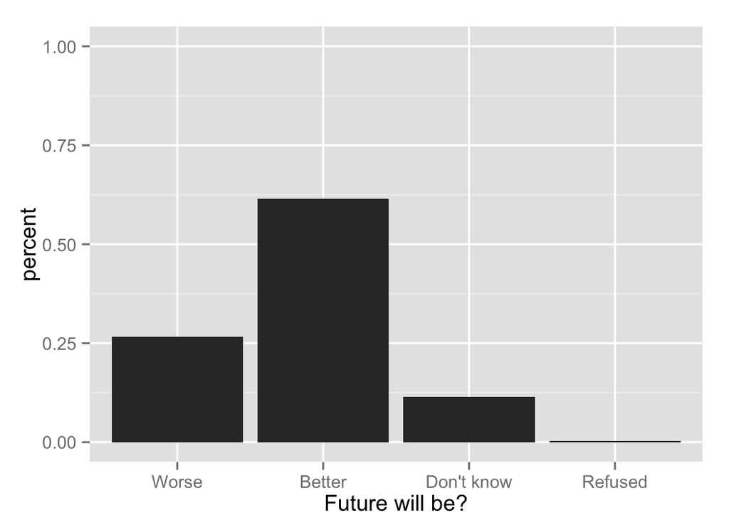

```
## Source: local data frame [2 x 2]
##
##   pial1b == 2   n
## 1       FALSE 197
## 2        TRUE 314
```

61.4% (314/511) think the future gets better.

## PIAL 2-a: Computers like human will happen?

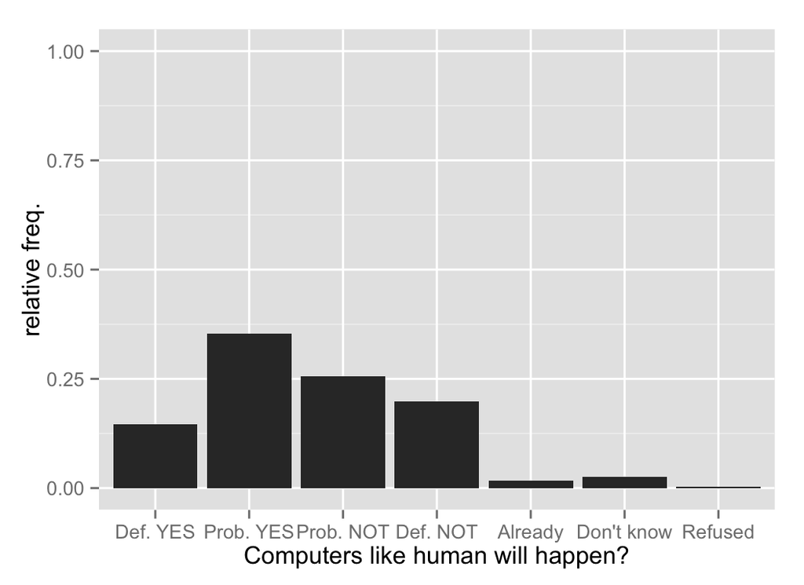

## PIAL 2-b: Lab-made organs will happen?

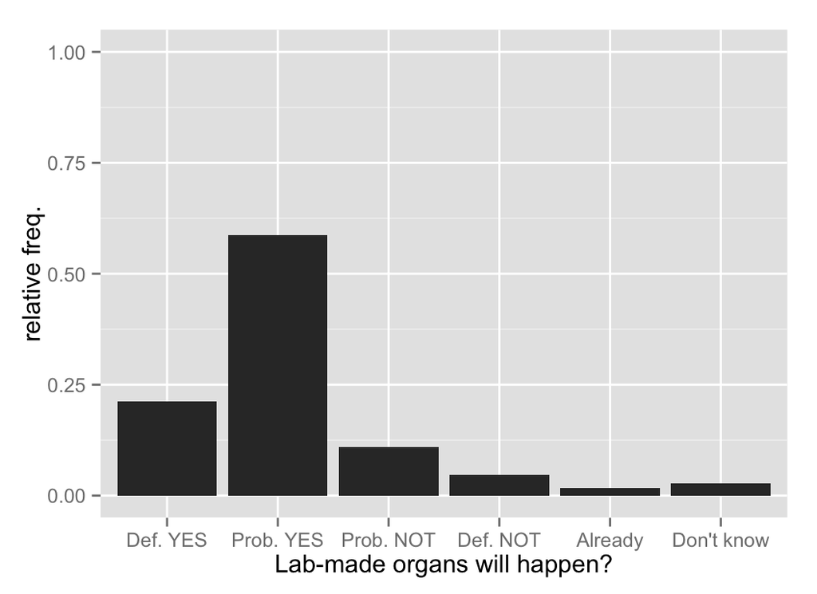

## PIAL 2-c: Colonies on another planet will happen?

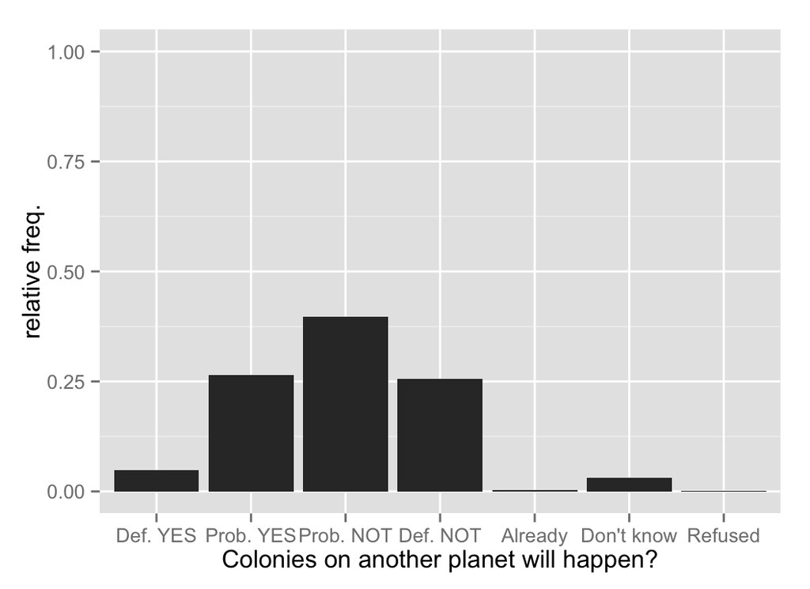

## PIAL 2-d: Weather control will happen?

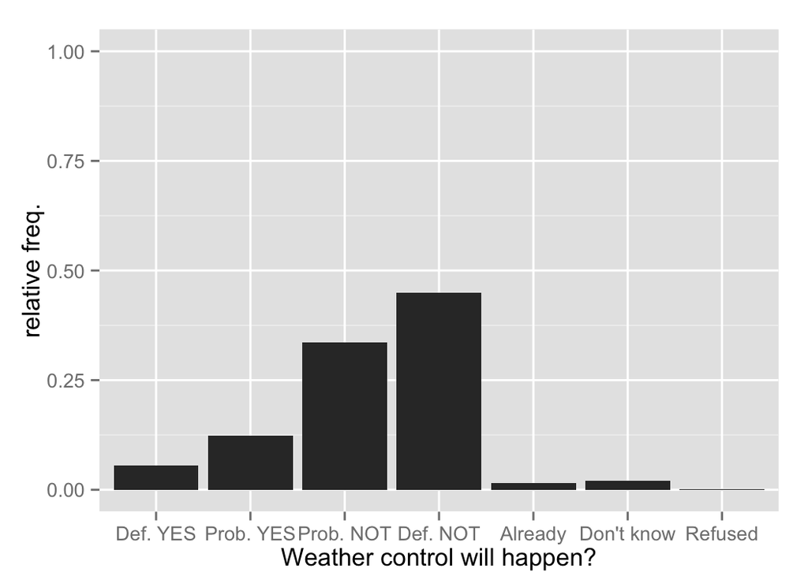

## PIAL 2-e: Teleportation will happen?

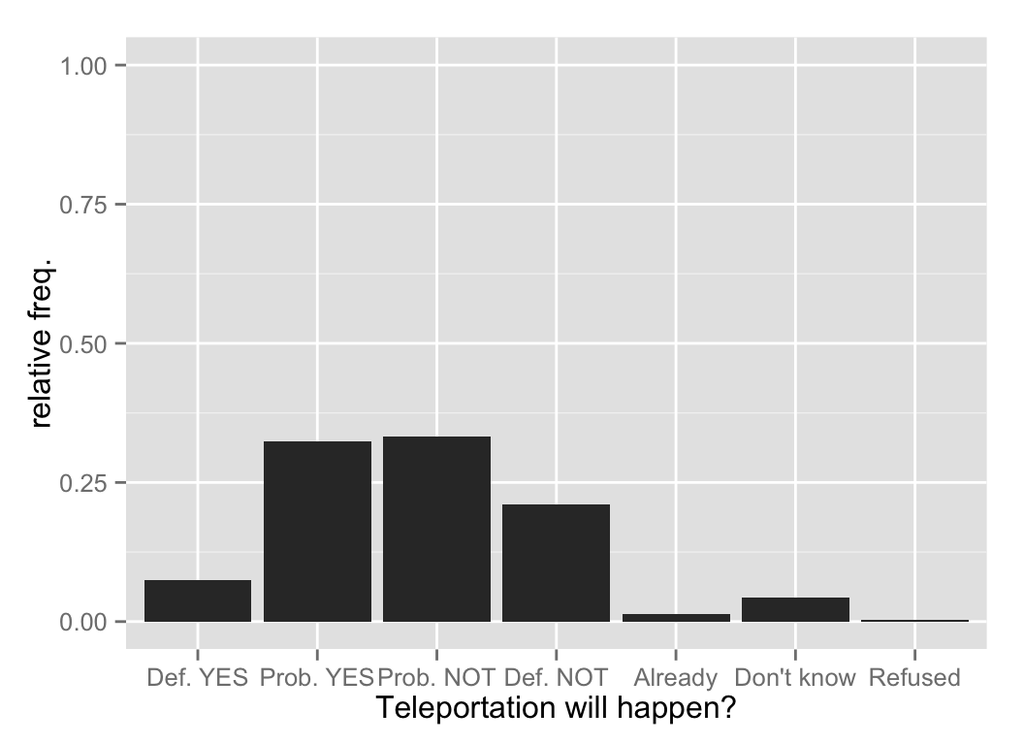

## PIAL 3-a: Lifelike robots are a change for Better or Worse?

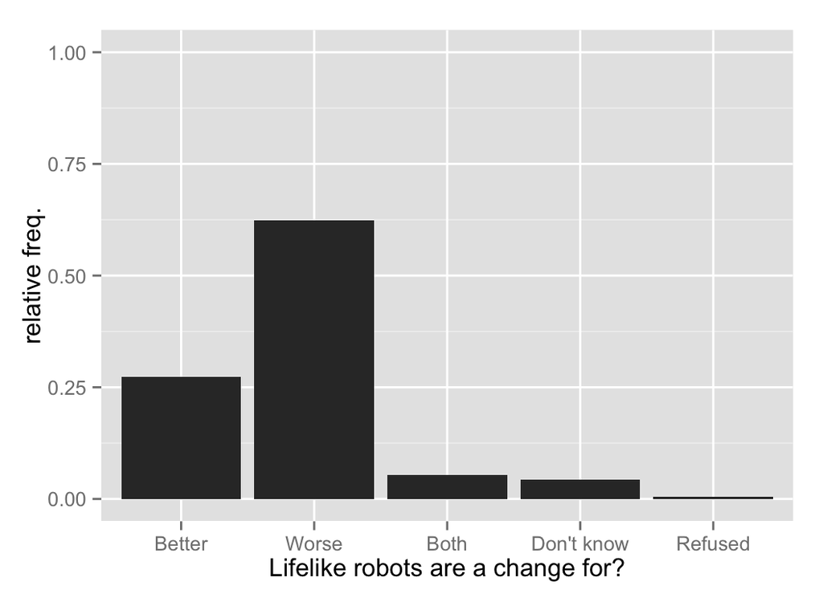

## PIAL 3-b: Drones are a change for Better or Worse?

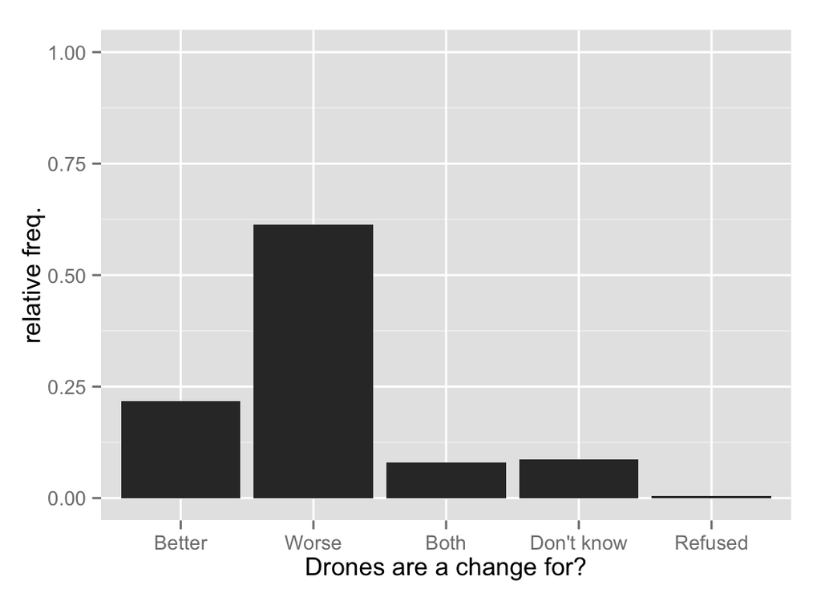

## PIAL 3-c: Wearable devices are a change for Better or Worse?

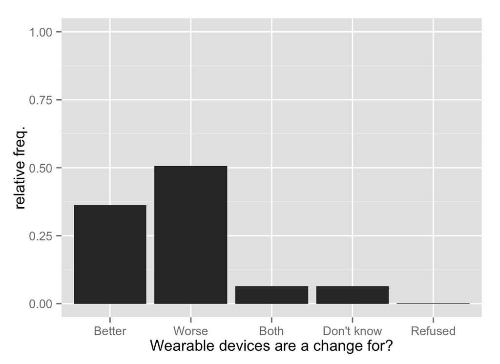

## PIAL 3-d: Altering DNA is a change for Better or Worse?

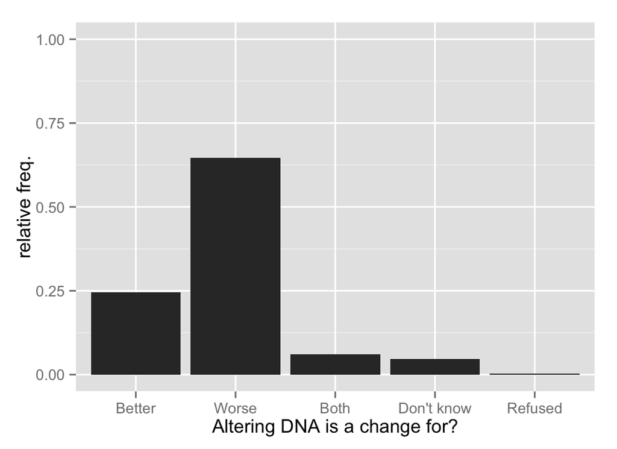

## Future vs. Income

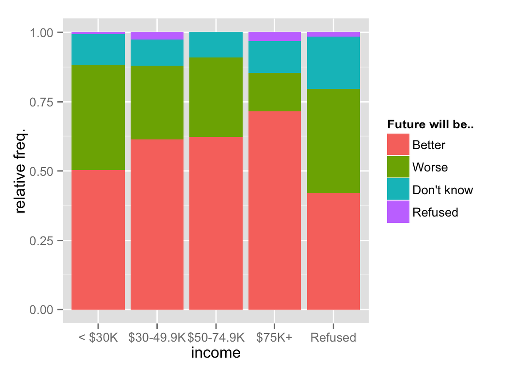

## Future vs. Sex

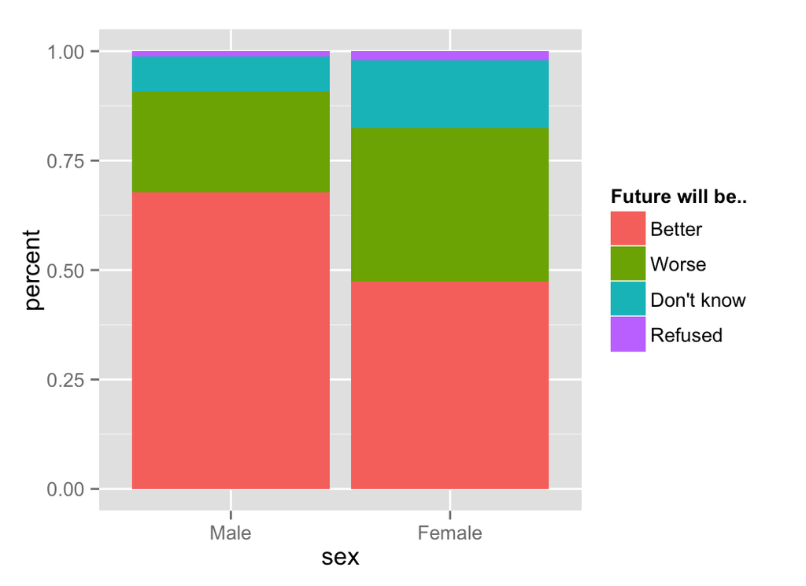

## View on Technology vs. Sex

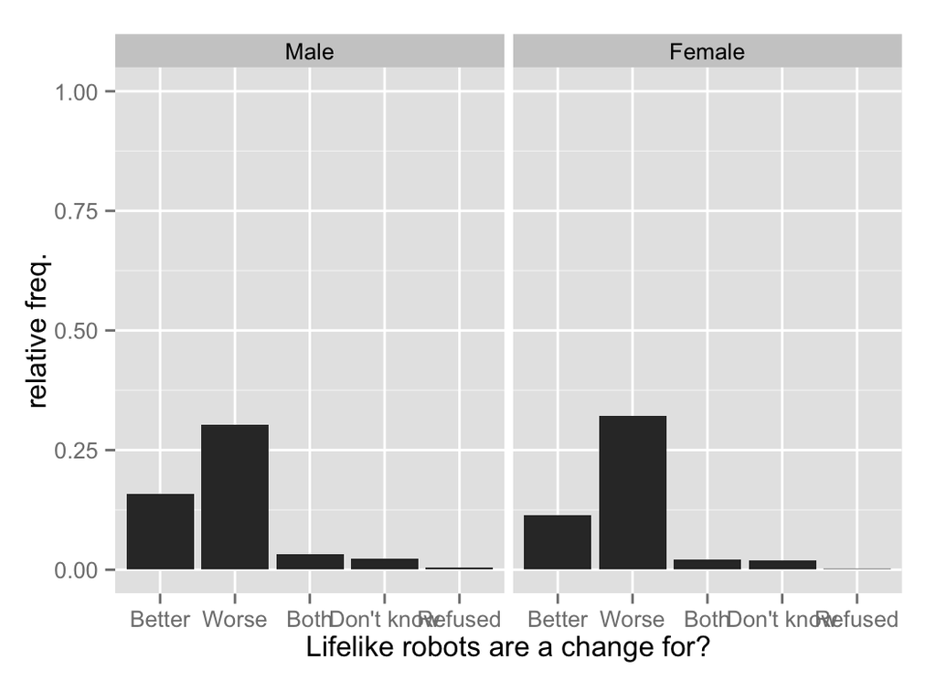

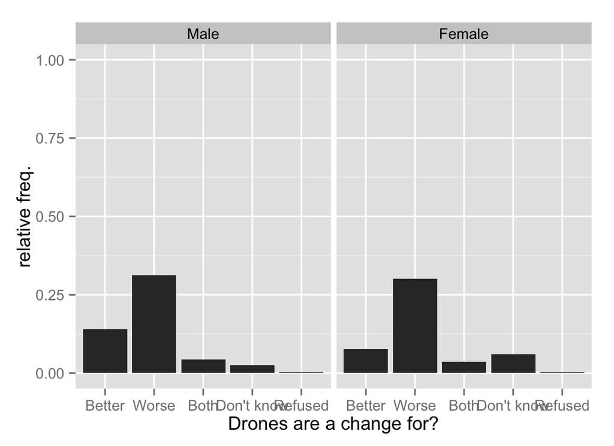

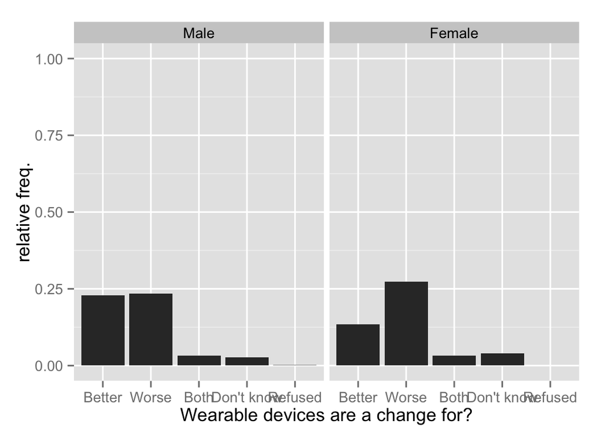

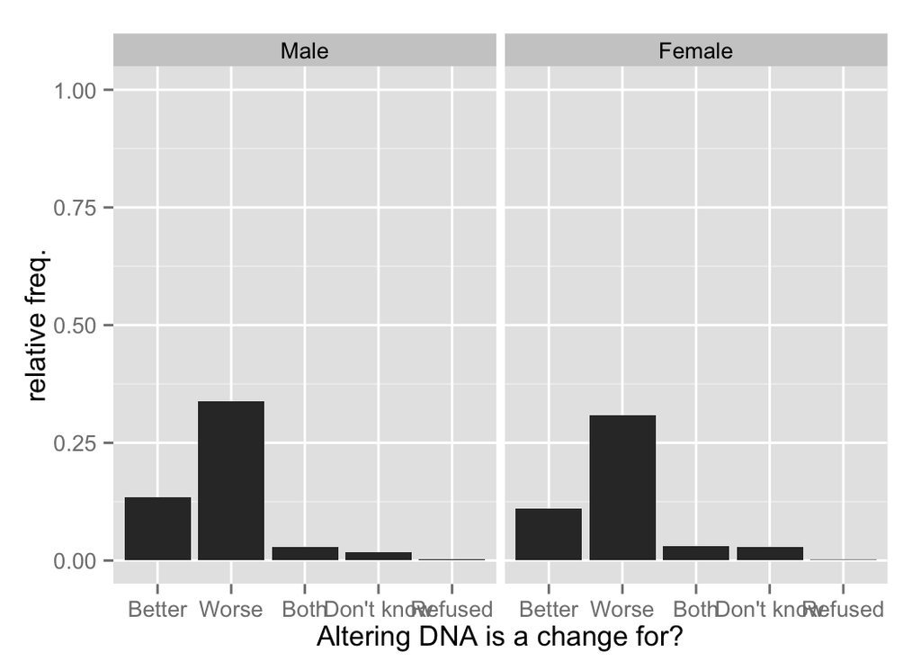

## View on Technology vs. Income

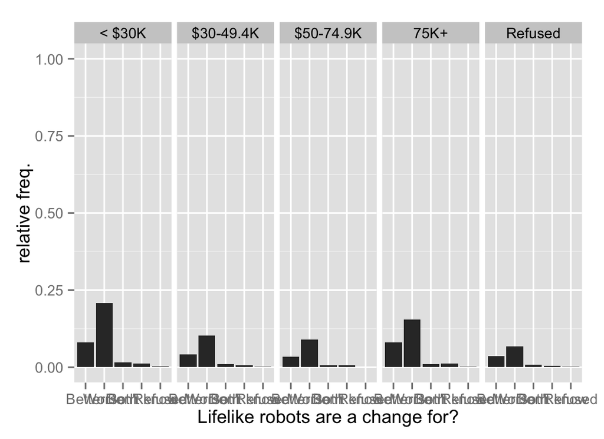

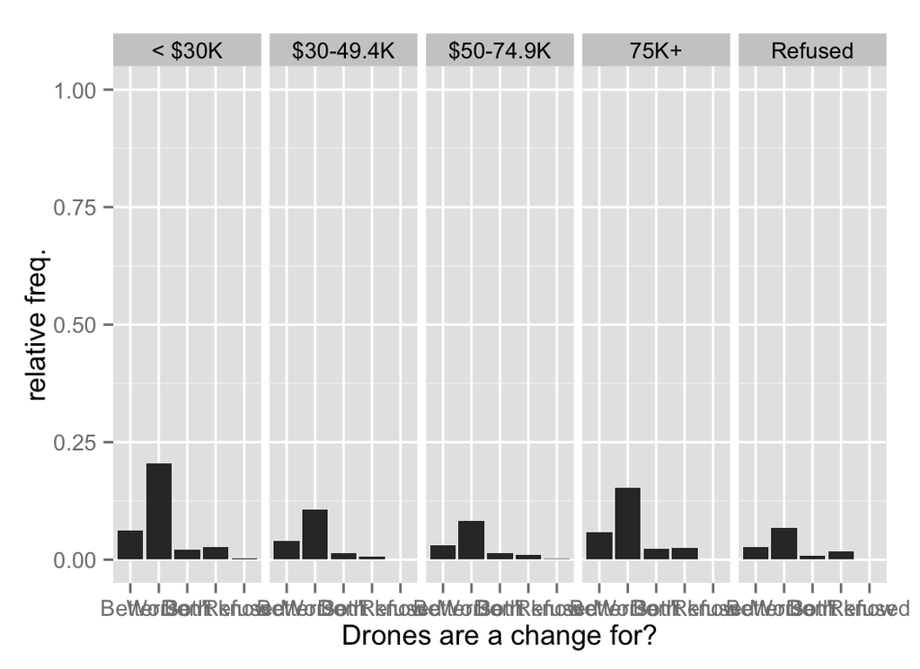

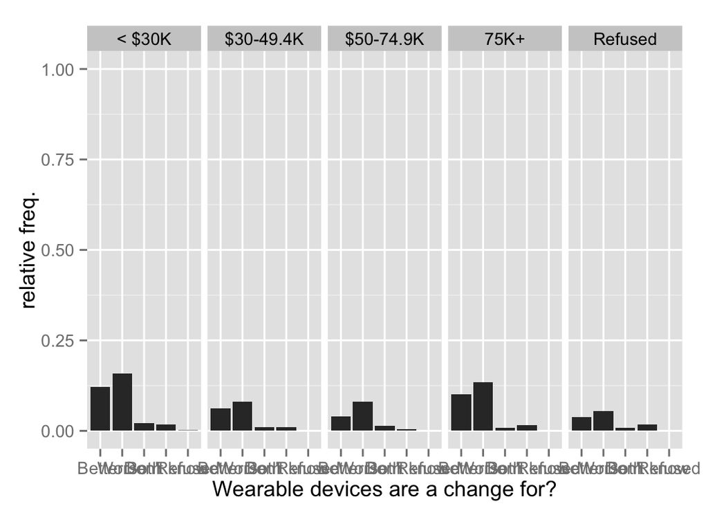

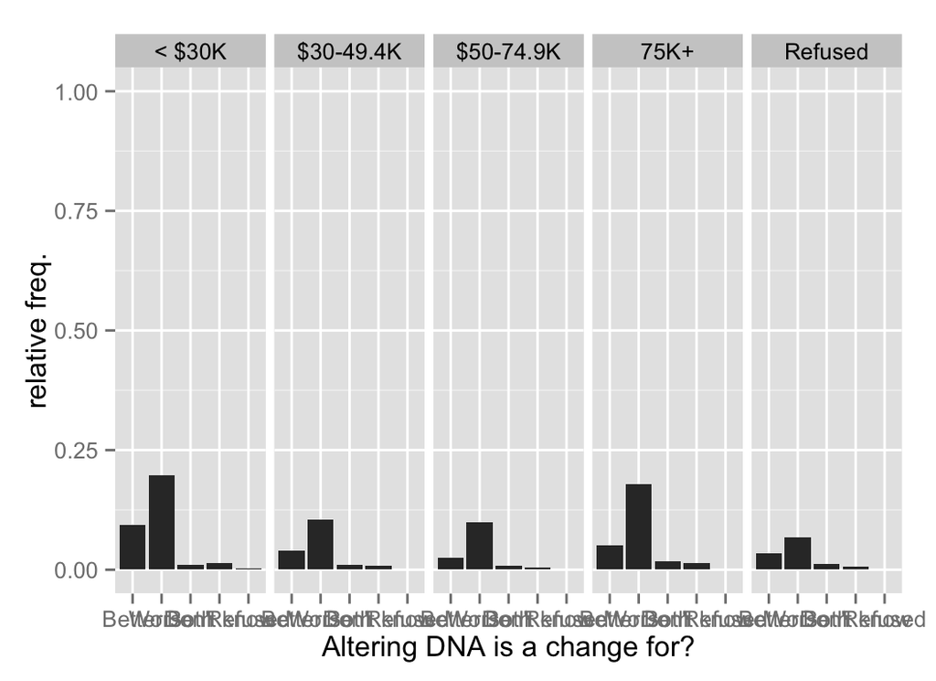

## Distribution of Income

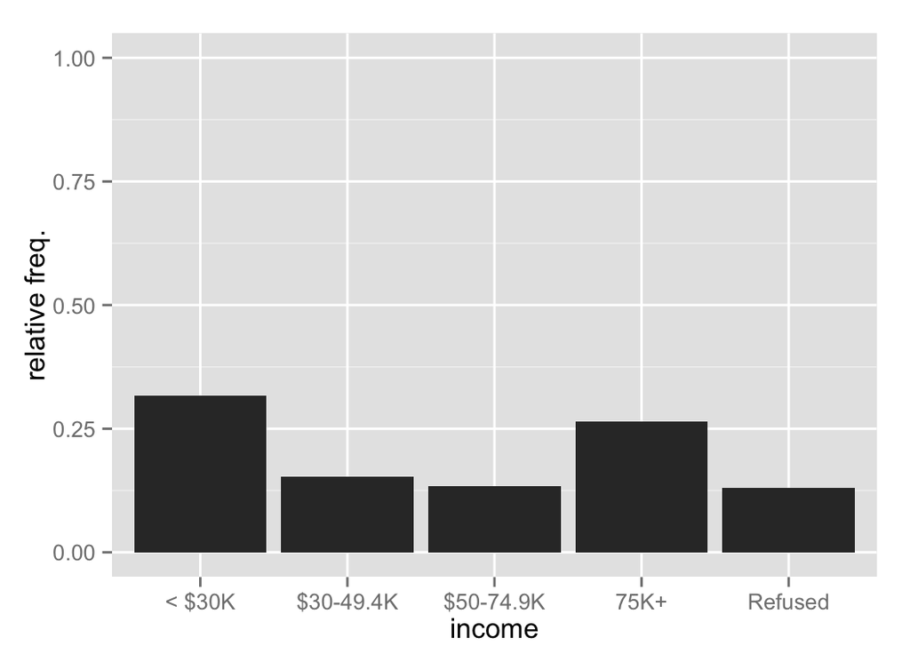

## PIAL2-a vs. PIAL1A

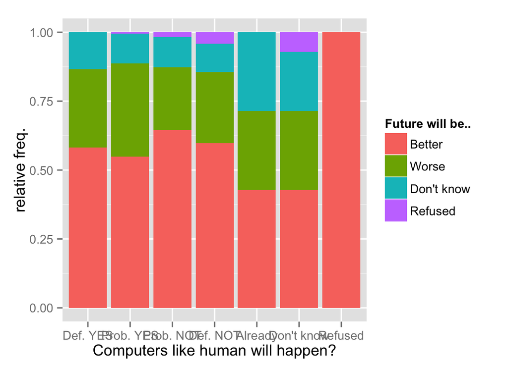

## PIAL2-b vs. PIAL1A

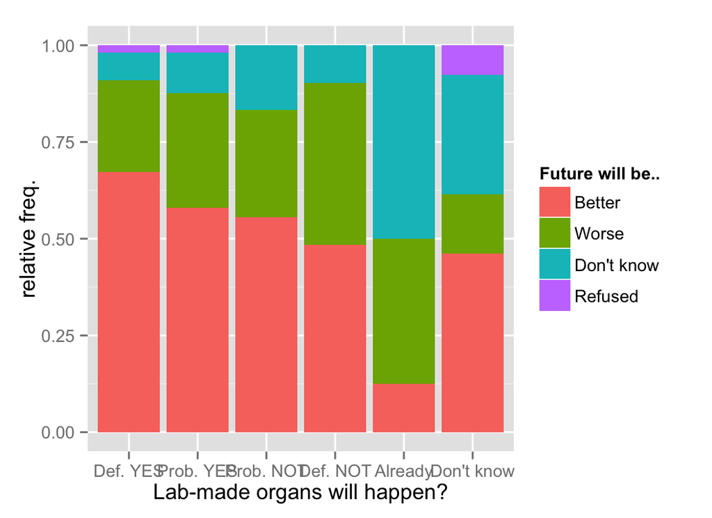

## PIAL2-c vs. PIAL1A

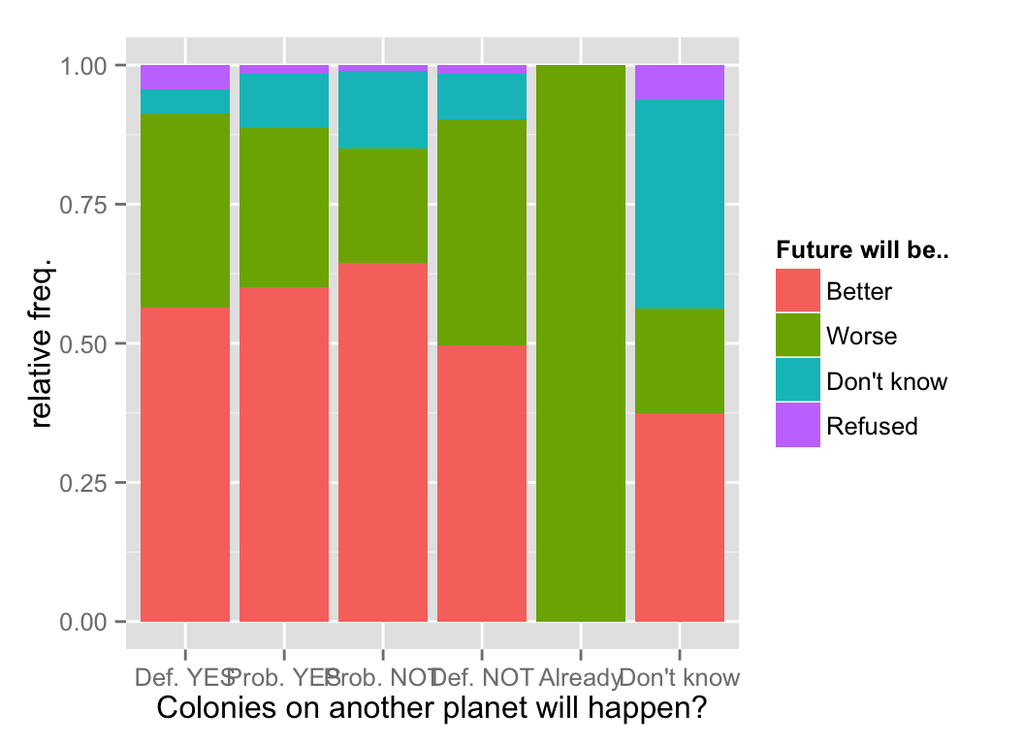

## PIAL2-d vs. PIAL1A

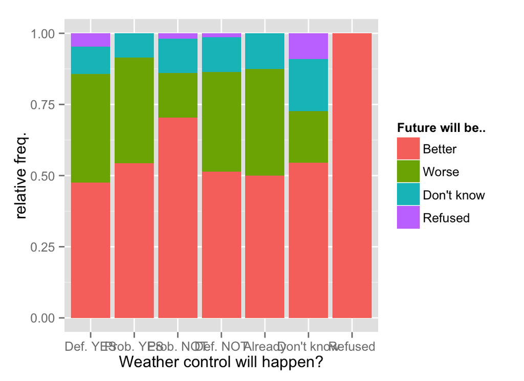

## PIAL2-e vs. PIAL1A

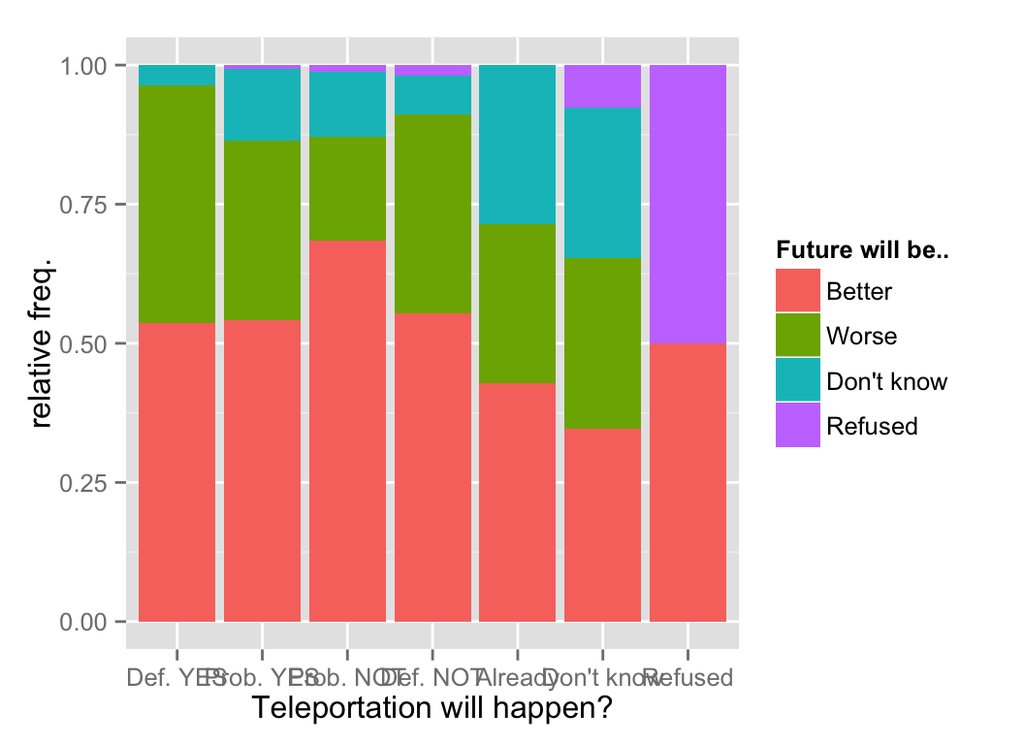

## PIAL4-a: Do you eat meat or not that was grown in a lab?

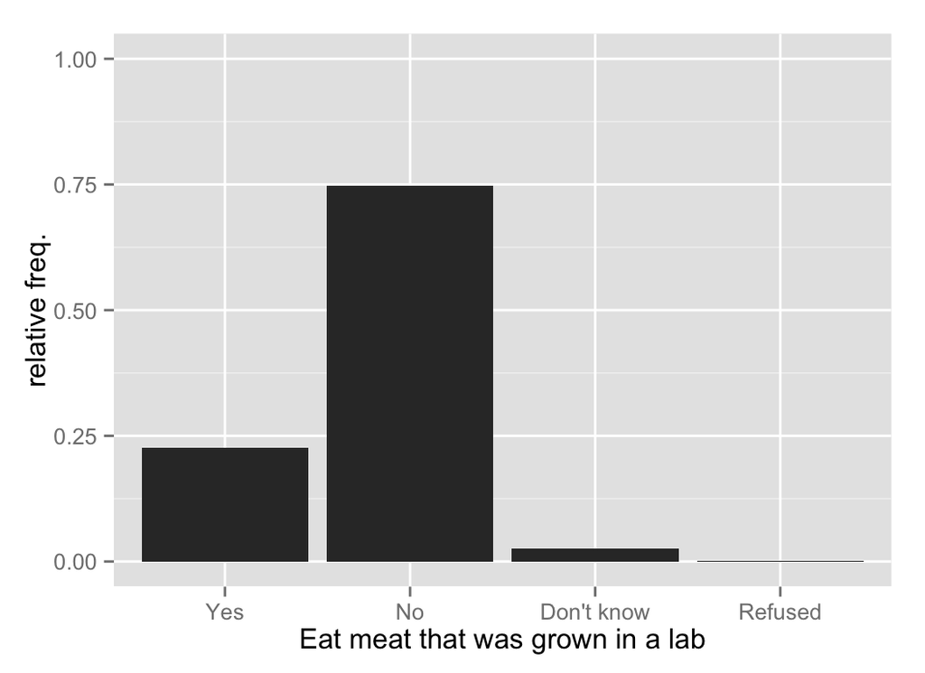

## PIAL4-b: Do you ride or not in a driverless car?

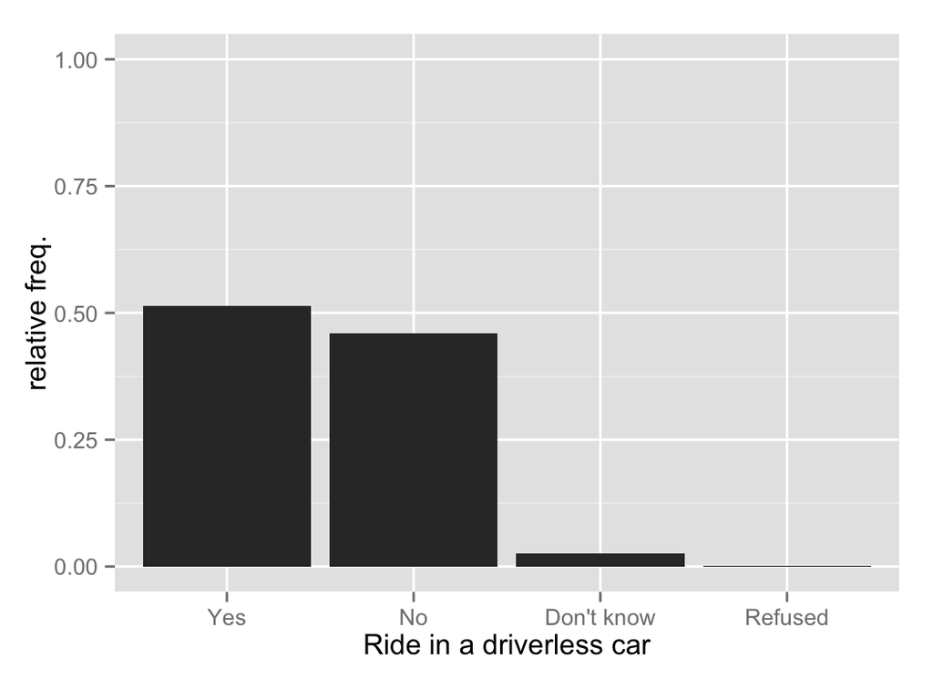

## PIAL4-c: Do you get or not a brain implant to improve your memory or mental capacity?

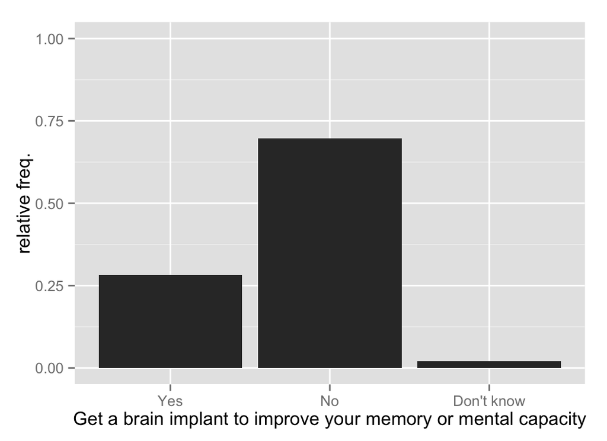

## PIAL4-a vs. 1-a

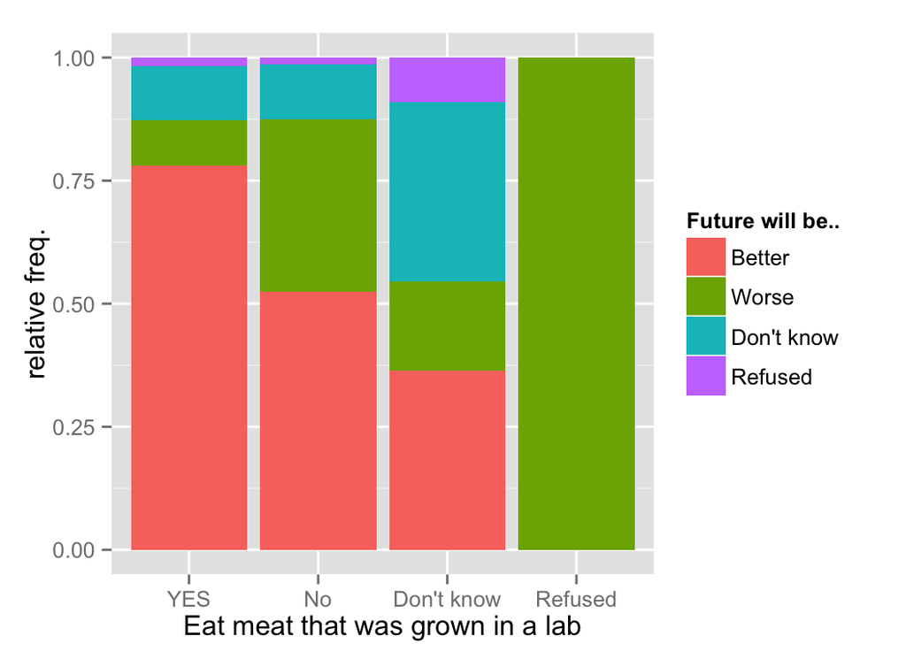